# BoardGame Geek Exploratory Analysis pt.1

Gabriele Baldassarre

2017-12-11

# Introduction

This is the first approach in exploring the BoardGameGeek dataset. I’m working on trying to answer the question *What constituted the perfect Board Game?* This is a very broad question and cannot be answered without a deep knowledge of the data itself.

In this kernel I’m going to show the exploratory analysis I performed on the data and my conclusions.

Although it’s not possible to cover all the possibile features of the dataset, I’m going to go as deeper I can on the most peculiar elements.

# Preprocessing the Data

Before starting, I’m going to filter out all those boardgames that has less than 5 user ratings and all the expansions. This will help me cleaning the dataset, as games with less than 5 ratings are probably:

- Unpublished Games
- Homebrew or hobbyst projects
- Adult variants of popular games
- In general, forgettable games which is safe to ignore.

Aside that, I’m going to wipe out boardgames *expansions* too, as they follow their own dynamic evolutions. For example, they tend to inherit the rating from the father, although they’re good or not by themselves.

Since we’re going to study the behaviours of **board games** only, it’s safe to remove expansions. too.

```r
corr.palette <- wes_palette(name="Darjeeling", 3, type = "continuous")

data("BoardGames")

bgg.useful <- BoardGames %>%
  bgg.prepare.data() %>%
  filter(!is.na(details.yearpublished)) %>%
  filter(details.yearpublished <= 2016) %>%
  filter(details.yearpublished >= 1960) %>%
  filter(stats.usersrated >= 5, game.type == "boardgame") %>%
  mutate(stats.average.factor = arules::discretize(stats.average,
                                           method="frequency",
                                           categories = 5,
                                           ordered = TRUE))

rownames(bgg.useful) <- make.names(bgg.useful$details.name, unique=TRUE)
```

At the end of the day, we’ve a nice, good looking dataset made of 27829 official, certified games to play with.

# Year Distribution of Games

In the Board Game industries, things have started to be interesting because of the “Eurogame Revolution”, where young and talented designers from Europe, and Germany in particular, introduced new design patterns which highly improved the quality of the games so far. Historians says it happened aroun the turn of the century.

I’m going to check if it’s true exploring the year and rating distributions of the data.

First of all, let’s see how many games are published per year.

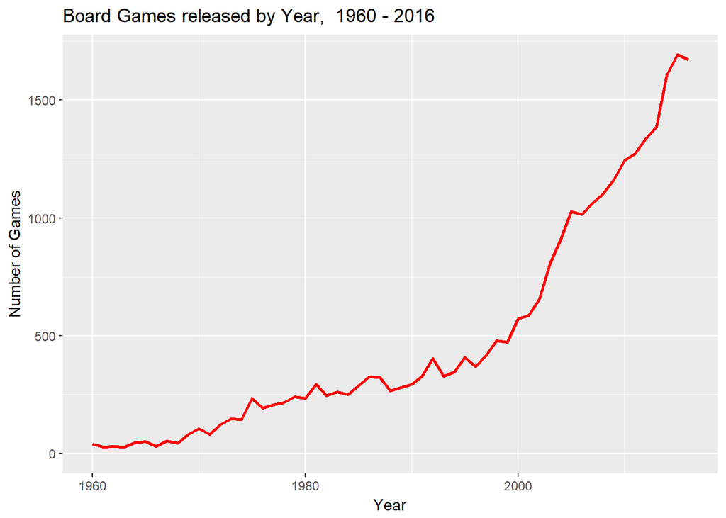

```r
# summarize by year
boardgames.by.years <- bgg.useful %>%
  mutate(details.yearpublished=as.numeric(details.yearpublished)) %>%
  filter(!is.na(details.yearpublished)) %>%
  filter(details.yearpublished <= 2016) %>%
  group_by(details.yearpublished) %>%
  dplyr::summarise(count = n())


# we got a 7700 missing and 1q=1994, Median=2006
ggplot(boardgames.by.years,aes(details.yearpublished,count)) +
  geom_line(col="red", lwd=1) +
  ggtitle(paste('Board Games released by Year, ', min(boardgames.by.years$details.yearpublished),'-', max(boardgames.by.years$details.yearpublished))) +
  xlab('Year') +
  ylab("Number of Games") +
  ylim(c(0,max(boardgames.by.years$count)))
```

This is somewhat expected: the number of game published per year radically **exploded** around the turn of the century!

This huge increase is significant? Can I safely remove all those ancient games from before the revolution from the population, thus better focusing my sample?

To aestimate that, let’s plot the cumulative frequency of games among time and check the median.

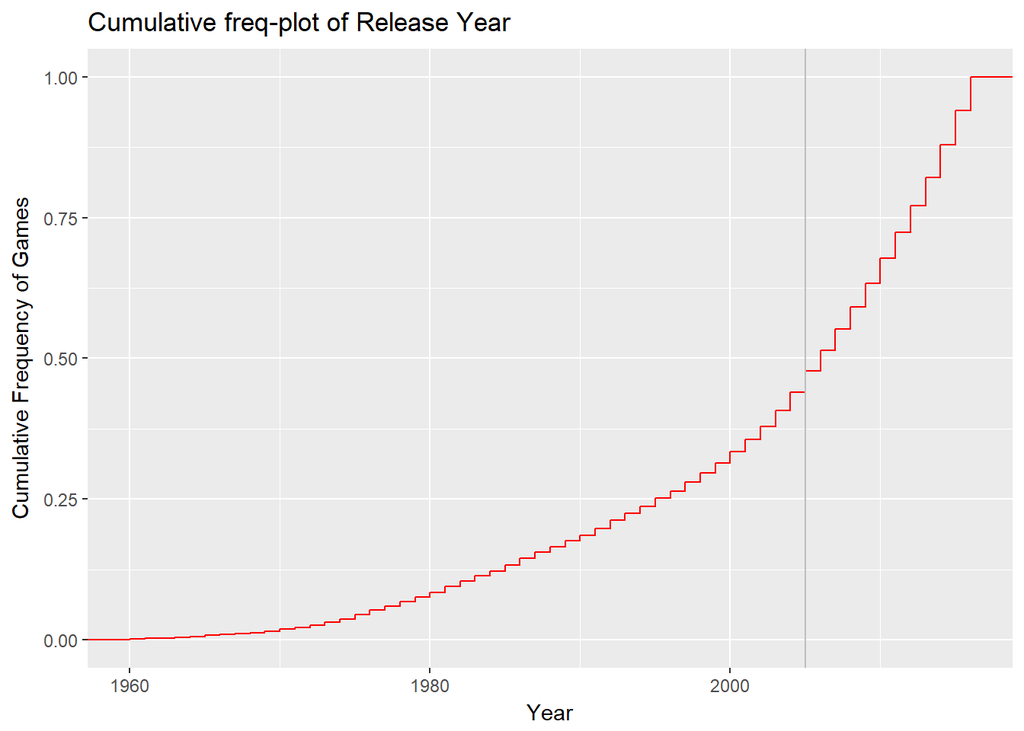

```r
# Cumulative Freq-plot of year (median in grey)
ggplot(bgg.useful, aes(as.numeric(details.yearpublished))) +
  stat_ecdf(geom="step", lwd=.5, col="red") +
  ggtitle("Cumulative freq-plot of Release Year") +
  xlab('Year') +
  ylab("Cumulative Frequency of Games") +
  geom_vline(xintercept=median(as.numeric(BoardGames$details.yearpublished), na.rm=TRUE), color = 'grey')
```

Median is on 2005, which suggest that *recent* (ie. during-post eurogame revolution) games significally describe the dataset. We’re definitively on the spike, now.

# Examining the Rating Distribution

Now, let’s go deeper about the *quality* of those games. First of all, we’re going to check the normality of the average ratings for games in the population.

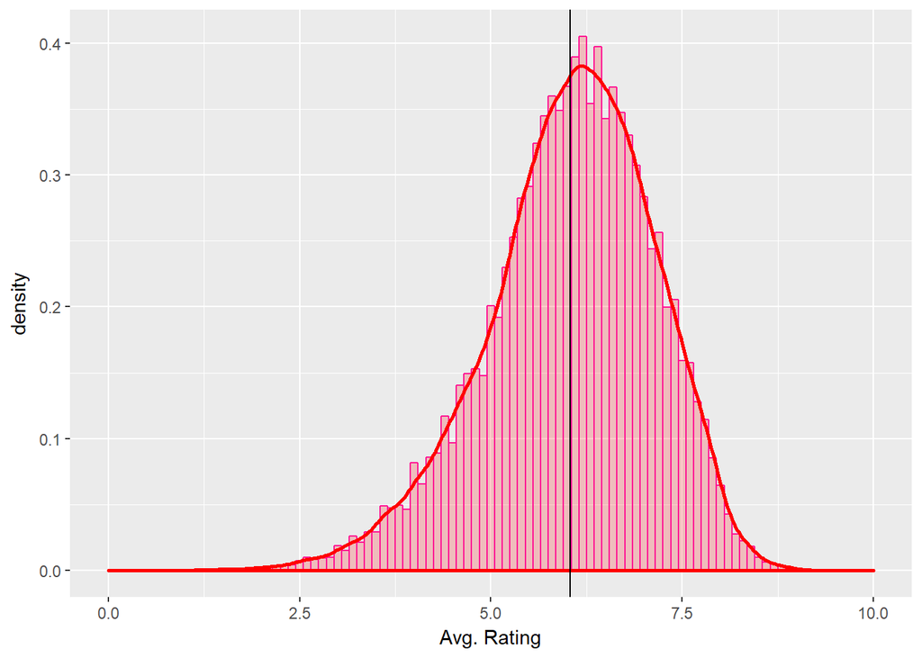

```r
# Rating Distribution
ggplot(bgg.useful, aes(x = stats.average)) +
  geom_histogram(aes(y = ..density..), binwidth = .1, fill="red", alpha=.2, col="deeppink") + geom_density(col="red", lwd=1) +
  xlim(0,10) +
  xlab('Avg. Rating') +
  geom_vline(xintercept=mean(bgg.useful$stats.average, na.rm=TRUE), color="black")
```

I think there’re no doubts that rating follow the normal distribution :) This is unsurprising, but it’s always cool to see a so good looking bell-shaped distribution, nowdays!

Anyway, a better look for the quality of games among times is when we summarize in groups of 5 years each:

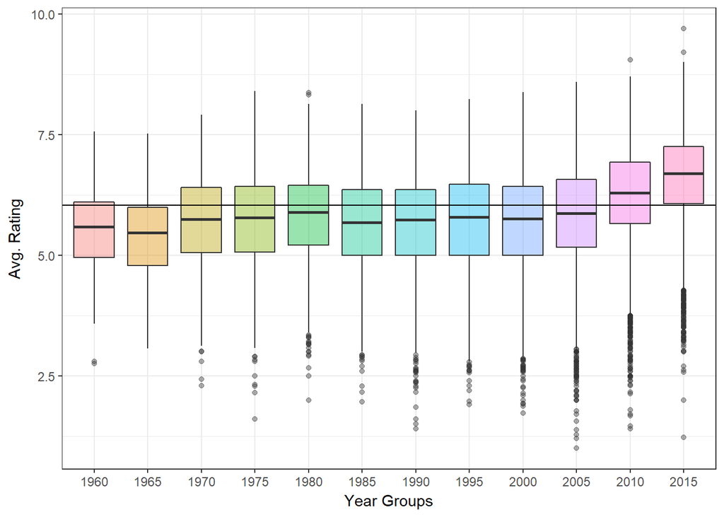

```r
# Splitting by year class
ggplot(bgg.useful %>%
         mutate(year.discrete=as.factor(plyr::round_any(as.numeric(details.yearpublished), 5))) %>%
         filter(as.numeric(details.yearpublished) >=1960 & as.numeric(details.yearpublished) <= 2016)
       , aes(year.discrete, stats.average, fill=year.discrete)) +
  geom_boxplot(alpha=.4) +
  theme_bw() +
  ylab("Avg. Rating") + xlab("Year Groups") +
  geom_hline(yintercept=mean(bgg.useful$stats.average, na.rm=TRUE), color="black") +
  theme(legend.position="none")
```

Perhaps in the 2000s the *number* of published boardgames suddenly increased, but it was in the 2010s only that higher quality products started to emerge.

## Details and Ratings

I’m going to study the *details* variables, like playing time, average weight (difficulty), number of players, and the Rating: the idea here is to undestand if a particular detail could bring a game on top.

Some of the *details* columns are aestimations from the community, so I decided to filter games with less than 100 ratings. This would lend, I guess, to a less biased sample.

Just for start, I’m going to perform a simple correlation plot.

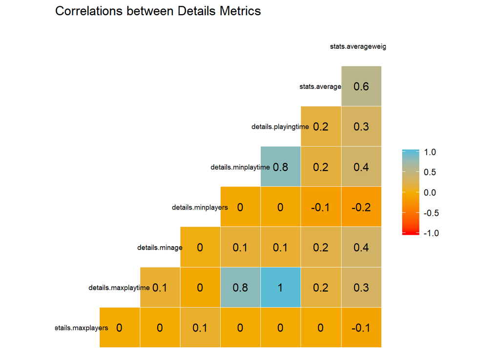

```r
ggcorr(data = bgg.useful %>%
  filter(stats.usersrated >= 100) %>%
  select(starts_with("details"),
         stats.average,
         stats.averageweight,
         -ends_with(".factor"),
         -details.name,
         -details.yearpublished)
  ,
       label = TRUE,
       geom = "tile",
       low = corr.palette[1],
       mid = corr.palette[2],
       high = corr.palette[3],
       midpoint=0,
       size = 2.5) +
  ggtitle("Correlations between Details Metrics")
```

There’re not so many interesting relations here. Clearly, *playingtime*, *maxplayingtime* and *minplayingtime* are strongly related. I will probably drop two of three of them while training a regression or performing a PCA as they won’t carry much variance to the dataset. Said that, it’s business as usual here.

Another slighlty relation is between the minimum age for playing the game and the difficulty of the game itself (*averageweight*). I was expecting that, as impegnative games are not usually suitable for children.

Another empirical knowledge about Board Games says that, if we exclude Party Games, games that involves many players, tend to last longer. Surprisily enough, there’s no correlation between *maxplayers* and *maxplayingtime*. I’m going to analyze the root causes here while working on categories: my idea is that there’re some two-players only games that unskew the distribution: the Historical WarGames (I will return on this later).

Last but not least, the positive correlation between Ratings and Weight. Users seems to prefer though games.

The BoardGameGeek community is perhaps be made by hardcore gamers?

## This game is fu*in’ hard!

Ok, users in BGG prefer heavy games. But how many of those are in the database?

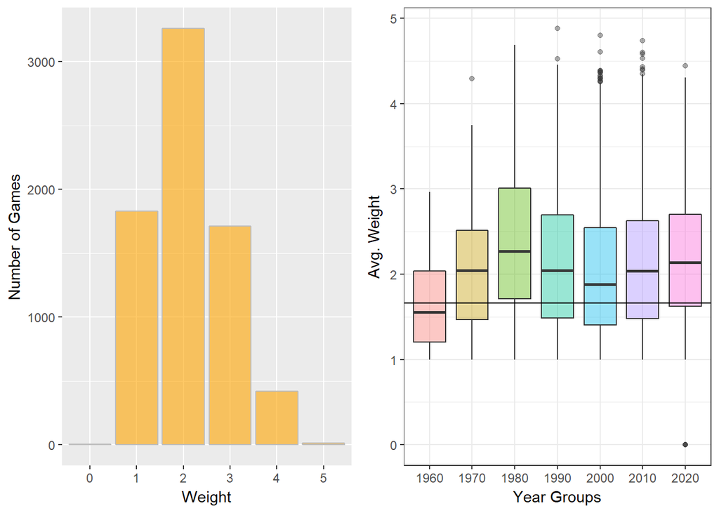

```r
multiplot(
ggplot(bgg.useful %>%
         filter(as.numeric(details.yearpublished) >=1960 & as.numeric(details.yearpublished) <= 2016) %>%
         filter(stats.usersrated >= 100)
       , aes(x = stats.weight.factor)) +
  geom_histogram(binwidth=1, stat="count", fill="orange", alpha=.6, col="grey") +
  xlab("Weight") + ylab("Number of Games")
,
ggplot(bgg.useful %>%
         mutate(year.discrete=as.factor(round_any(as.numeric(details.yearpublished), 10))) %>%
         filter(as.numeric(details.yearpublished) >=1960 & as.numeric(details.yearpublished) <= 2016) %>%
         filter(stats.usersrated >= 100)
       , aes(year.discrete, stats.averageweight, fill=year.discrete)) +
  geom_boxplot(alpha=.4) +
  theme_bw() +
  ylab("Avg. Weight") + xlab("Year Groups") +
  geom_hline(yintercept=mean(bgg.useful$stats.averageweight, na.rm=TRUE), color="black") +
  theme(legend.position="none")
, cols=2)
```

Clearly, the average weight is not so high as the users’ preference would suggests instead: the most common games recorded in the database is definitively **simple** (Weight = 2)!

What happened during the 80s and the 90s? I’m going to chech this while digging on categories/mechanics (Historians say that was the golden era of Wargames. This would be an explanation indeed).

Let’s assess the quality and the popularity of those games, too…

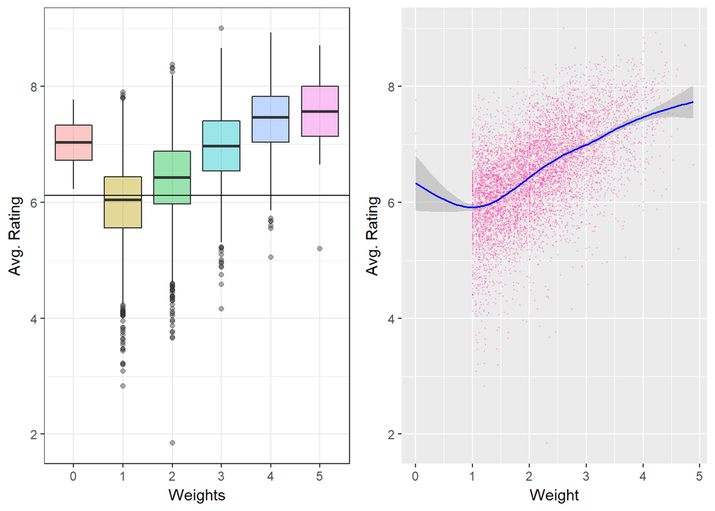

```r
multiplot(
ggplot(bgg.useful %>%
         filter(as.numeric(details.yearpublished) >=1960 & as.numeric(details.yearpublished) <= 2016) %>%
         filter(stats.usersrated >= 100)
       , aes(stats.weight.factor, stats.average, fill=stats.weight.factor)) +
  geom_boxplot(alpha=.4) +
  theme_bw() +
  ylab("Avg. Rating") +
  xlab("Weights") +
  geom_hline(yintercept=median(bgg.useful$stats.average, na.rm=TRUE), color="black") +
  theme(legend.position="none")
  ,
ggplot(bgg.useful %>%
       filter(as.numeric(details.yearpublished) >=1960 & as.numeric(details.yearpublished) <= 2016)
       %>% filter(stats.usersrated >= 100)
       , aes(stats.averageweight, stats.average)) +
  geom_point(alpha=.2, lwd=.2, col="deeppink") +
  geom_smooth(col="blue", lwd=.7) +
  ylab("Avg. Rating") +
  xlab("Weight")
, cols=2)
```

Really, they prefer those heavy bricks.

But they buy them?

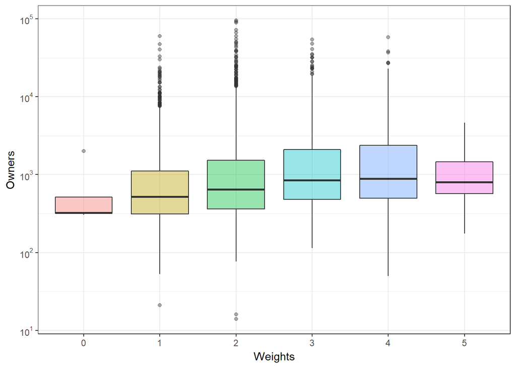

```r
ggplot(bgg.useful %>%
         filter(as.numeric(details.yearpublished) >=1960 & as.numeric(details.yearpublished) <= 2016) %>%
         filter(stats.usersrated >= 100)
       , aes(stats.weight.factor, stats.owned, fill=stats.weight.factor)) +
  geom_boxplot(alpha=.4) +
  theme_bw() +
  ylab("Owners") + scale_y_log10(breaks = trans_breaks("log10", function(x) 10^x),
                                      labels = trans_format("log10", math_format(10^.x))
                                      ) +
  xlab("Weights") +
  theme(legend.position="none")
```

Well…more or less… :)

## Popularity and Ratings

BoardGameGeek has the reputation of being a very competent community. To check this, let’s see if there is a correlation between game rating and game **popularity**.

The idea is to proxy the popularity using the numbers of users who *rated* the games and the numbers of users who *own* the games.

I’ve filtered all those games with a number of ratings less than 10: no matter what they say, those games are not popular!

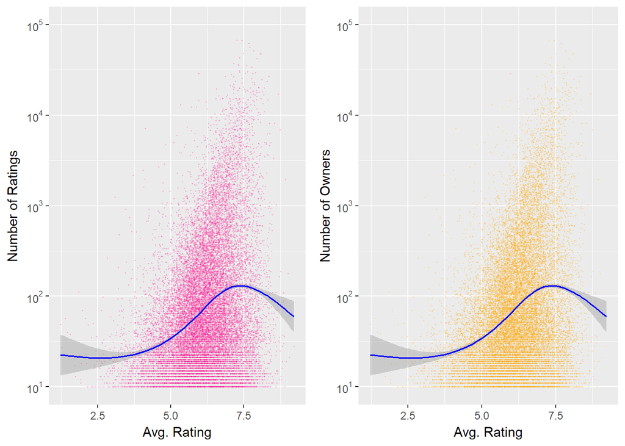

```r
multiplot(
  ggplot(bgg.useful
         %>% filter(stats.usersrated >= 10)
         , aes(stats.average, stats.usersrated)) +
    geom_point(alpha=.2, lwd=.2, col="deeppink") +
    geom_smooth(col="blue", lwd=.7) +
    ylab("Number of Ratings") + scale_y_log10(breaks = trans_breaks("log10", function(x) 10^x),
                                              labels = trans_format("log10", math_format(10^.x)),
                                              limits = c(10,10^5)) +
    xlab("Avg. Rating"),
  ggplot(bgg.useful
         %>% filter(stats.usersrated >= 10)
         , aes(stats.average, stats.usersrated)) +
    geom_point(alpha=.2, lwd=.2, col="orange") +
    geom_smooth(col="blue", lwd=.7) +
    ylab("Number of Owners") + scale_y_log10(breaks = trans_breaks("log10", function(x) 10^x),
                                             labels = trans_format("log10", math_format(10^.x)),
                                             limits = c(10,10^5)) +
    xlab("Avg. Rating"),
  cols=2)
```

Clearly there is a positive correlation between both the dependants. People in the community tend to prefer more high-rated games. Much probably, correlation **is** causation here: highly rated games are the most popular and the best sellers (well, at least for the BoardGameGeek users!)

# Marketplace Metrics

The analysis above surfaced the idea of a relation between the rating and the popularity of a game. I want to go further and try to understand the **buying belief** for a given game, too.

I would start exploring the metrics which are related to the marketplace section of BoardGameGeek: for each game, we have the number of users *owning*, *wishing*, *wanting* and *trading* a game.

Are those metrics correlated and how they relate to the average rating?

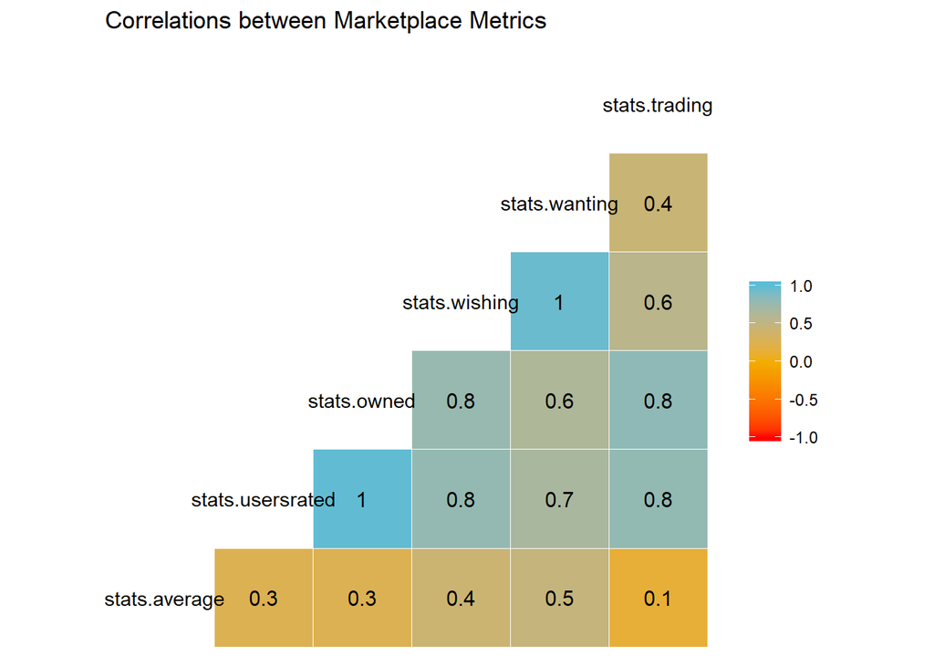

```r
bgg.marketplace.data <- bgg.useful[,c("stats.average",
                            "stats.usersrated",
                            "stats.owned",
                            "stats.wishing",
                            "stats.wanting",
                            "stats.trading",
                            "details.yearpublished")] %>% filter(stats.usersrated >= 100)

ggcorr(data = bgg.marketplace.data[,-which(names(bgg.marketplace.data) == "details.yearpublished")],
       label = TRUE,
       geom = "tile",
       low = corr.palette[1],
       mid = corr.palette[2],
       high = corr.palette[3],
       midpoint=0) +
  ggtitle("Correlations between Marketplace Metrics")
```

Again, I’ve wiped-out all those forgettable games with less than 100 Ratings.

We can see a strong positive correlation for almost all the marketplace metrics here. This is expecially true between the Number of Ratings (*stats.average*) and the Owners (*stats.owned*) and for people that put the game in the wishlist (*stats.wishing*) and those who are actively searching for buying it on the BGG Marketplace (*stats.wanting*).

As expected, the correlation between the latters, which carries a positive **buying belief**, are weakly correlated to those are selling the game on the Marketplace (*stats.trading*). But wait…is this still a positive correlation! This is really a counter-intuitive behaviour.

The problem here is that the Marketplace metrics are biased by the popularity of a game itself: the more a game is popular, the more **all** the marketplace metrics goes up.

To normalize the measurements, I’m going to add a derivate metric, **stats.trading.ratio**, defined as the ratio between the Number of Traders and the total Number of Owners. Then, I’m going to check the correlation matrix again…

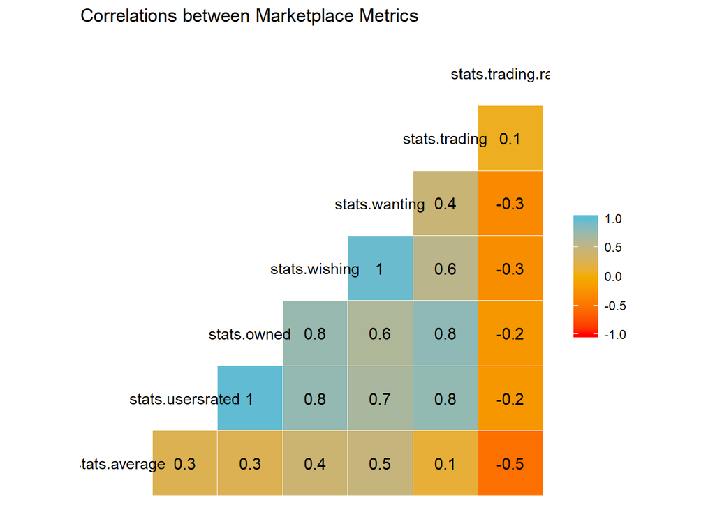

```r
ggcorr(data = bgg.marketplace.data[,-which(names(bgg.marketplace.data) == "details.yearpublished")]
                %>% mutate(stats.trading.ratio=stats.trading/stats.owned)
                %>% filter(stats.trading.ratio <= .2),
       label = TRUE,
       geom = "tile",
       low = corr.palette[1],
       mid = corr.palette[2],
       high = corr.palette[3],
       midpoint=0) +
  ggtitle("Correlations between Marketplace Metrics")
```

…and the negative coefficient will start to pop up.

It looks like that the Game Rating influenced the number of copies sold (*stats.owned*) **AND** the interest in the long-term (*stats.trading.ratio*). This are something that deserve more attention, so let’s study the distributions of these three variables.

Game Designers usually don’t like Traders because for any guy selling his copy of the Game there is a lost opportunity to sell a game expansions, so it’s important to undestand…*what influence the Traders?*

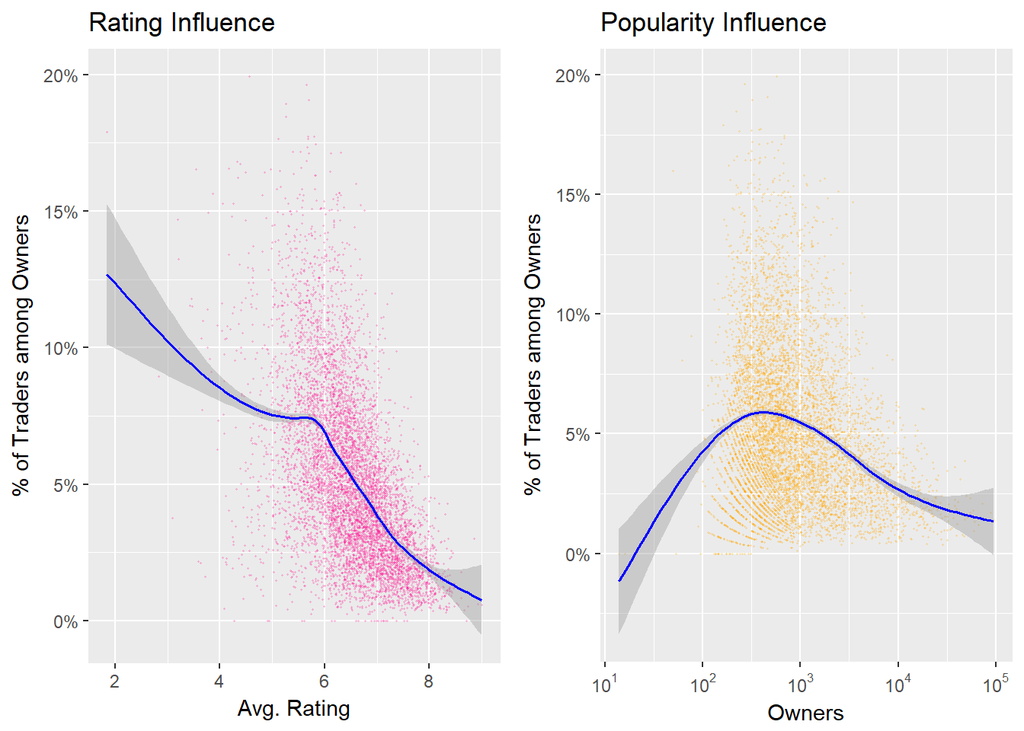

```r
multiplot(
ggplot(bgg.marketplace.data
         %>% mutate(stats.trading.ratio=stats.trading/stats.owned)
         %>% filter(stats.trading.ratio <= .2)
       , aes(stats.average, stats.trading.ratio)) +
  geom_point(alpha=.2, lwd=.2, col="deeppink") +
  geom_smooth(col="blue", lwd=.7) +
  ylab("% of Traders among Owners") + scale_y_continuous(labels=percent) +
  xlab("Avg. Rating") +
  ggtitle("Rating Influence")
  ,
ggplot(bgg.marketplace.data
         %>% mutate(stats.trading.ratio=stats.trading/stats.owned)
         %>% filter(stats.trading.ratio <= .2)
       , aes((stats.owned), stats.trading.ratio)) +
  geom_point(alpha=.2, lwd=.2, col="orange") +
  geom_smooth(col="blue", lwd=.7) +
  ylab("% of Traders among Owners") + scale_y_continuous(labels=percent) +
  xlab("Owners") + scale_x_log10(breaks = trans_breaks("log10", function(x) 10^x),
                                       labels = trans_format("log10", math_format(10^.x))) +
  ggtitle("Popularity Influence")
  , cols=2)
```

(I’ve wiped out all those games which have a Trading Ratio more than 20%: these are outliers as they are beyond the 90% percentile.)

I like those plots because they give me some kind of thresolds. While nothing can be said about the latter, I’m quite confident in stating that a game with an Average Rating > 6 has more probability of lying in the perfect geeks’ skaffold for a long time.

Does a game lie in a safe zone even if its Rating is low, but supposing it’s a popular game?

Probably not, but let’s check:

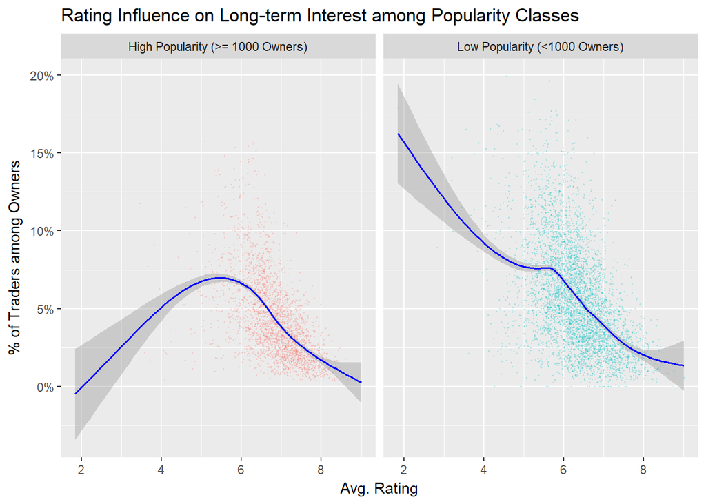

```r
ggplot(bgg.marketplace.data
       %>% mutate(stats.trading.ratio=stats.trading/stats.owned)
       %>% mutate(attribute.popularity=ifelse(stats.owned<10^3, "Low Popularity (<1000 Owners)", "High Popularity (>= 1000 Owners)"))
       %>% filter(stats.trading.ratio <= .2)
       , aes(stats.average, stats.trading.ratio, colour=attribute.popularity)) +
  geom_point(alpha=.2, lwd=.2) +
  geom_smooth(col="blue", lwd=.7, fullrange=TRUE) +
  ylab("% of Traders among Owners") + scale_y_continuous(labels=percent) +
  xlab("Avg. Rating") +
  facet_grid(. ~ attribute.popularity) +
  ggtitle("Rating Influence on Long-term Interest among Popularity Classes") +
  theme(legend.position="none")
```

To be popular on BGG, a game **must** be highly rated. No way!

Of course, older a game, higher the chances for it of being sold…

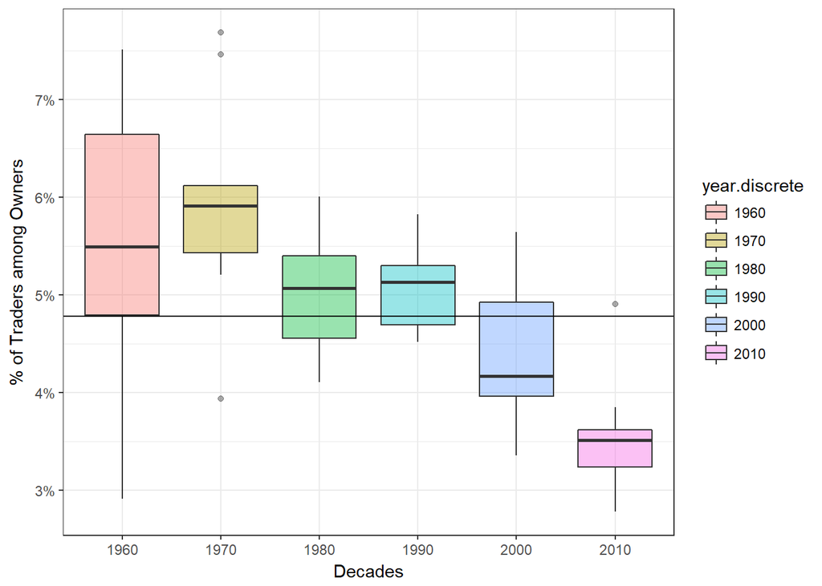

```r
boardgames.traders.by.years <- (((bgg.useful[,c("details.yearpublished", "stats.average", "stats.usersrated","stats.owned", "stats.wishing", "stats.wanting", "stats.trading")]) %>%
  mutate(details.yearpublished=as.numeric(details.yearpublished)) %>%
  mutate(stats.trading.ratio=stats.trading/stats.owned) %>%
  filter(!is.na(details.yearpublished)) %>%
  filter(details.yearpublished <= 2016) %>%
  #filter(stats.trading.ratio <= .2) %>%
  filter(stats.owned >= 100) %>%
  group_by(details.yearpublished) %>%
  dplyr::summarise(stats.trading = sum(stats.trading), stats.owned = sum(stats.owned)))  %>% mutate(stats.trading.ratio=stats.trading/stats.owned))

# Splitting by year class
ggplot(boardgames.traders.by.years
         %>% mutate(year.discrete=as.factor(round_any(as.numeric(details.yearpublished), 10)))
         %>% filter(as.numeric(details.yearpublished) >=1960 & as.numeric(details.yearpublished) < 2015)
       , aes(year.discrete, stats.trading.ratio, fill=year.discrete)) +
  geom_boxplot(alpha=.4) +
  theme_bw() +
  ylab("% of Traders among Owners") + scale_y_continuous(labels=percent) +
  xlab("Decades") +
  geom_hline(yintercept=mean(boardgames.traders.by.years$stats.trading.ratio, na.rm=TRUE), color="black")
```

…but this cannot be true for *ancient* games (ie. 1960s, 1970s): they are probably sold because they are *boring* (ie. Average Rating is low).

To assess this, let’s check if a game suffer an interest drop-off with time.

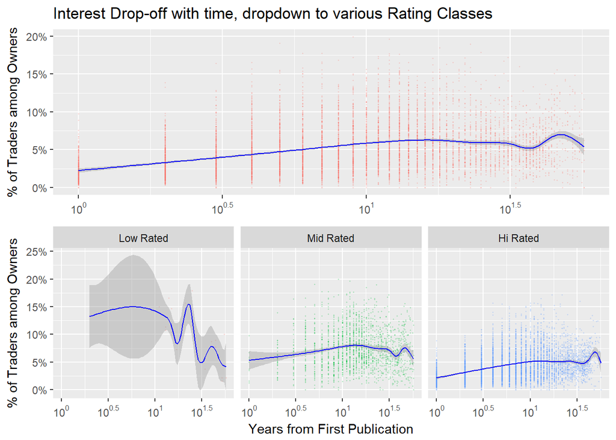

```r
multiplot(
ggplot(bgg.marketplace.data
       %>% mutate(stats.trading.ratio=stats.trading/stats.owned)
       %>% mutate(details.age=(2017 - details.yearpublished))
       %>% filter(stats.trading.ratio <= .2)
       , aes(details.age, stats.trading.ratio, col="orange")) +
  geom_point(alpha=.2, lwd=.2) +
  geom_smooth(col="blue", lwd=.5) +
  ylab("% of Traders among Owners") + scale_y_continuous(labels=percent) +
  xlab(NULL) + scale_x_log10(breaks = trans_breaks("log10", function(x) 10^x),
                                       labels = trans_format("log10", math_format(10^.x))) +
  ggtitle("Interest Drop-off with time, dropdown to various Rating Classes") +
  theme(legend.position="none")
,
ggplot(bgg.marketplace.data
       %>% mutate(stats.trading.ratio=stats.trading/stats.owned)
       %>% mutate(details.age=(2017 - details.yearpublished))
       %>% mutate(stats.rating.class=factor(ifelse(stats.average <= 4, "Low Rated", ifelse(stats.average <= 6, "Mid Rated", "Hi Rated")), levels=c("Low Rated", "Mid Rated", "Hi Rated")))
       %>% filter(stats.trading.ratio <= .2)
       , aes(details.age, stats.trading.ratio, col=stats.rating.class)) +
  geom_point(alpha=.2, lwd=.2) +
  geom_smooth(col="blue", lwd=.5) +
  ylab("% of Traders among Owners") + scale_y_continuous(labels=percent) +
  xlab("Years from First Publication") + scale_x_log10(breaks = trans_breaks("log10", function(x) 10^x),
                                       labels = trans_format("log10", math_format(10^.x))) +
  facet_grid(. ~ stats.rating.class) +
  theme(legend.position="none")
)
```

Although with different slopes between Mid and Hi Rated games, games tend to suffer an interest loss not earlier than 10-15 years after the first publication.

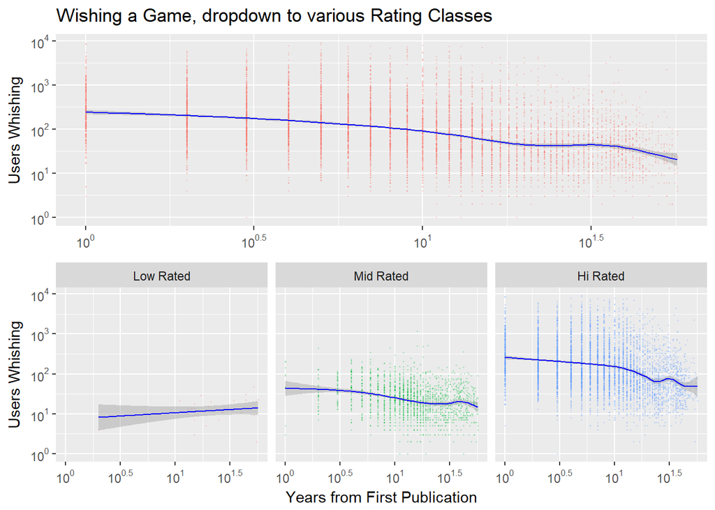

```r
multiplot(
ggplot(bgg.marketplace.data
       %>% mutate(details.age=(2017 - details.yearpublished))
       , aes(details.age, stats.wishing, col="orange")) +
  geom_point(alpha=.2, lwd=.2) +
  geom_smooth(col="blue", lwd=.5) +
  ylab("Users Whishing") + scale_y_log10(breaks = trans_breaks("log10", function(x) 10^x),
                                       labels = trans_format("log10", math_format(10^.x))) +
  xlab(NULL) + scale_x_log10(breaks = trans_breaks("log10", function(x) 10^x),
                                       labels = trans_format("log10", math_format(10^.x))) +
  ggtitle("Wishing a Game, dropdown to various Rating Classes") +
  theme(legend.position="none")
,
ggplot(bgg.marketplace.data
       %>% mutate(details.age=(2017 - details.yearpublished))
       %>% mutate(stats.rating.class=factor(ifelse(stats.average <= 4, "Low Rated", ifelse(stats.average <= 6, "Mid Rated", "Hi Rated")), levels=c("Low Rated", "Mid Rated", "Hi Rated")))
       , aes(details.age, stats.wishing, col=stats.rating.class)) +
  geom_point(alpha=.2, lwd=.2) +
  geom_smooth(col="blue", lwd=.5) +
  ylab("Users Whishing") + scale_y_log10(breaks = trans_breaks("log10", function(x) 10^x),
                                       labels = trans_format("log10", math_format(10^.x))) +
  xlab("Years from First Publication") + scale_x_log10(breaks = trans_breaks("log10", function(x) 10^x),
                                       labels = trans_format("log10", math_format(10^.x))) +
  facet_grid(. ~ stats.rating.class) +
  theme(legend.position="none")
)
```